# Assignment 6: Visualization - Aesthetic Mapping

*How to do it?*:

- Open the Rmarkdown file of this assignment (link) in Rstudio.
- Right under each **question**, insert a code chunk (you can use the hotkey `Ctrl + Alt + I` to add a code chunk) and code the solution for the question.
- `Knit` the rmarkdown file (hotkey: `Ctrl + Alt + K`) to export an html.
- Publish the html file to your Githiub Page.

*Submission*: Submit the link on Github of the assignment to Canvas.

### Questions on Your Selected Data

Choose a dataset and produce the following types of plots and comment on each plot. Plots should be meaningful. If you use the data we used in class, make sure the plots are not the same as the ones in the slides.

```r
titanic <- read.csv("C:/Users/student/Downloads/titanic.csv")
```

1. For one continuous variable:
- Density

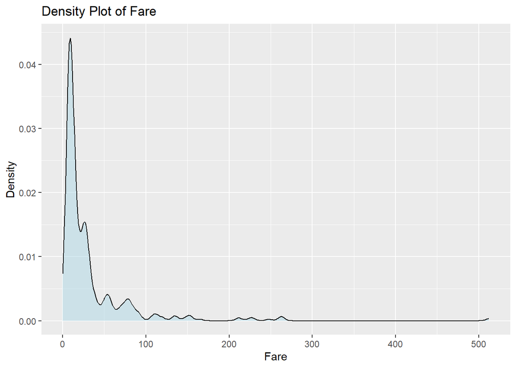

```r
library(ggplot2)

ggplot(titanic, aes(x = Fare)) +
  geom_density(fill = "lightblue", alpha = 0.5) +
  labs(title = "Density Plot of Fare", x = "Fare", y = "Density")
```

```r
#The density plot shows the distribution of passenger fares. Most of the fares are between 0 and 50.
```

- Histogram

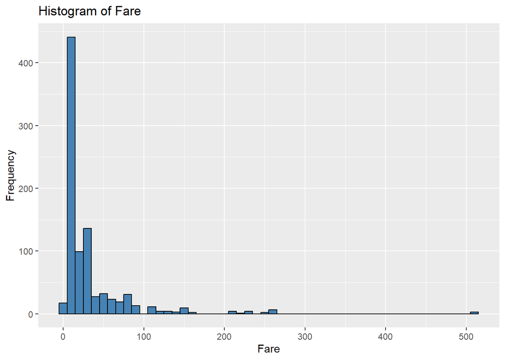

```r
ggplot(titanic, aes(x = Fare)) +
  geom_histogram(binwidth = 10, fill = "steelblue", color = "black") +
  labs(title = "Histogram of Fare", x = "Fare", y = "Frequency")
```

```r
#The histogram shows that a large number of passengers paid fares under 50, with far fewer paying higher amounts.
```

- Boxplot

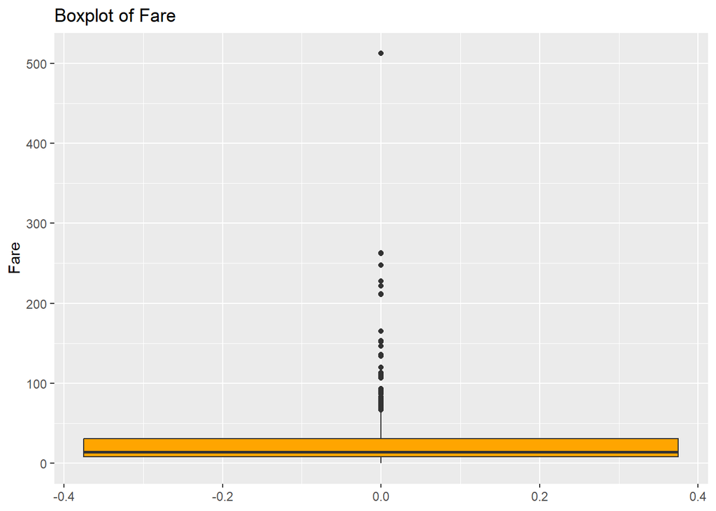

```r
ggplot(titanic, aes(y = Fare)) +
  geom_boxplot(fill = "orange") +
  labs(title = "Boxplot of Fare", y = "Fare")
```

```r
#This shows that most fares are clustered toward the lower end of the scale, with many extreme outliers
```

2. For one categorical variable
- Barplot

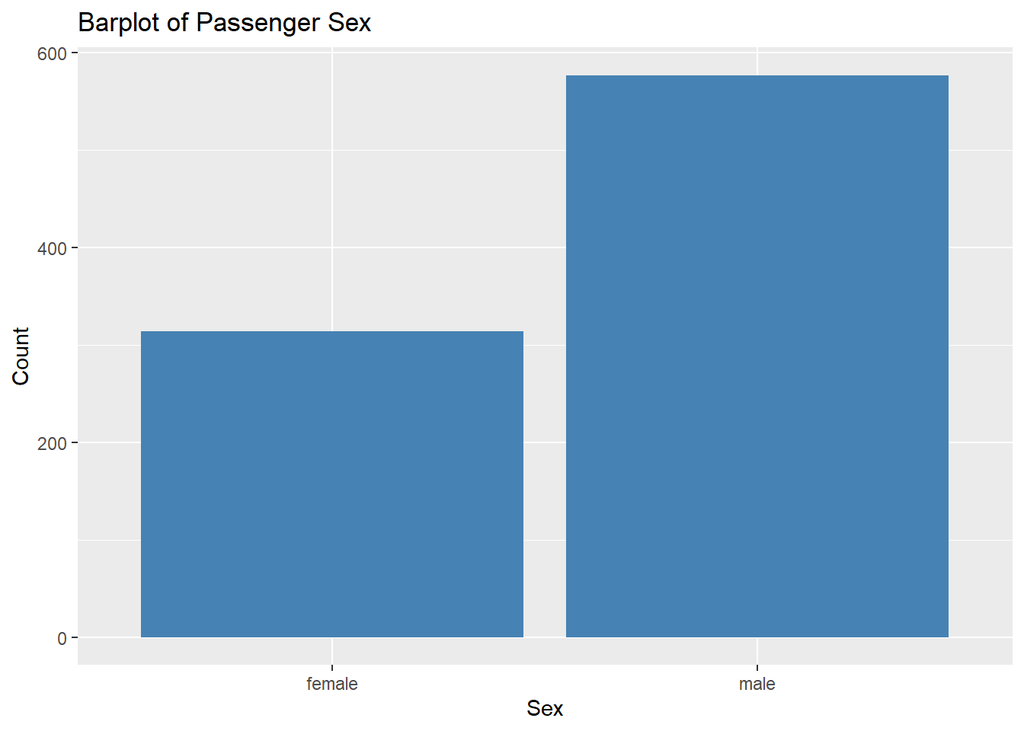

```r
library(ggplot2)

ggplot(titanic, aes(x = Sex)) +
  geom_bar(fill = "steelblue") +
  labs(title = "Barplot of Passenger Sex", x = "Sex", y = "Count")
```

```r
#This shows  the number of male and female passengers on the Titanic.
```

3. For two continuous variables
- Scatter Plot

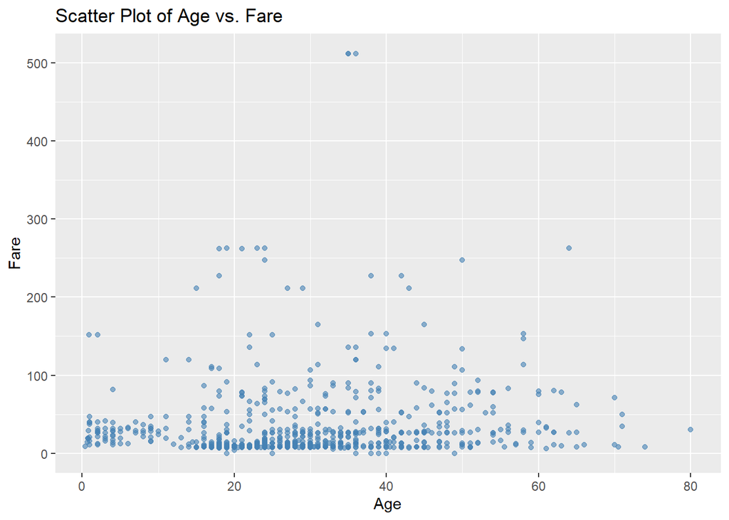

```r
library(ggplot2)

ggplot(titanic, aes(x = Age, y = Fare)) +
  geom_point(alpha = 0.6, color = "steelblue") +
  labs(title = "Scatter Plot of Age vs. Fare", x = "Age", y = "Fare")
```

```r
#This shows individual passengers’ Age versus Fare.
```

- Line Plot

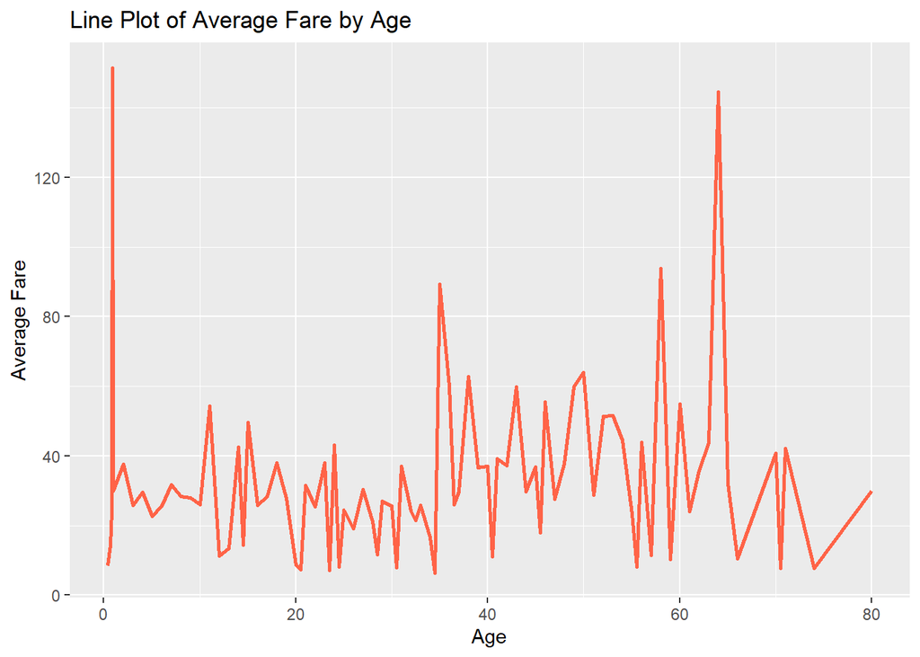

```r
library(dplyr)

avg_fare <- titanic %>%
  group_by(Age) %>%
  summarise(mean_fare = mean(Fare, na.rm = TRUE))

ggplot(avg_fare, aes(x = Age, y = mean_fare)) +
  geom_line(color = "tomato", size = 1) +
  labs(title = "Line Plot of Average Fare by Age", x = "Age", y = "Average Fare")
```

```r
#This shows how the average fare changes with passenger age
```

- Smooth Plot

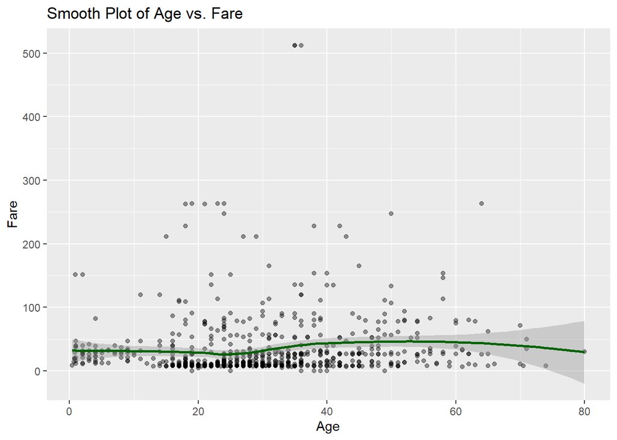

```r
ggplot(titanic, aes(x = Age, y = Fare)) +
  geom_point(alpha = 0.4) +
  geom_smooth(method = "loess", color = "darkgreen", se = TRUE) +
  labs(title = "Smooth Plot of Age vs. Fare", x = "Age", y = "Fare")
```

```r
#The smooth plot adds a trend line to the scatter plot. It confirms that fare does not consistently increase or decrease with age
```

4. For one continuous + one categorical variables
- Density

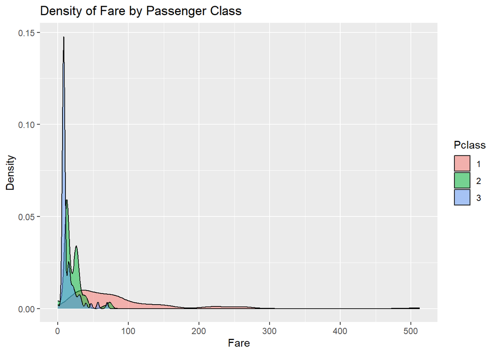

```r
library(ggplot2)

ggplot(titanic, aes(x = Fare, fill = factor(Pclass))) +
  geom_density(alpha = 0.5) +
  labs(title = "Density of Fare by Passenger Class", x = "Fare", y = "Density", fill = "Pclass")
```

```r
#This shows distribution of fares based on passenger class
```

- BoxPlot

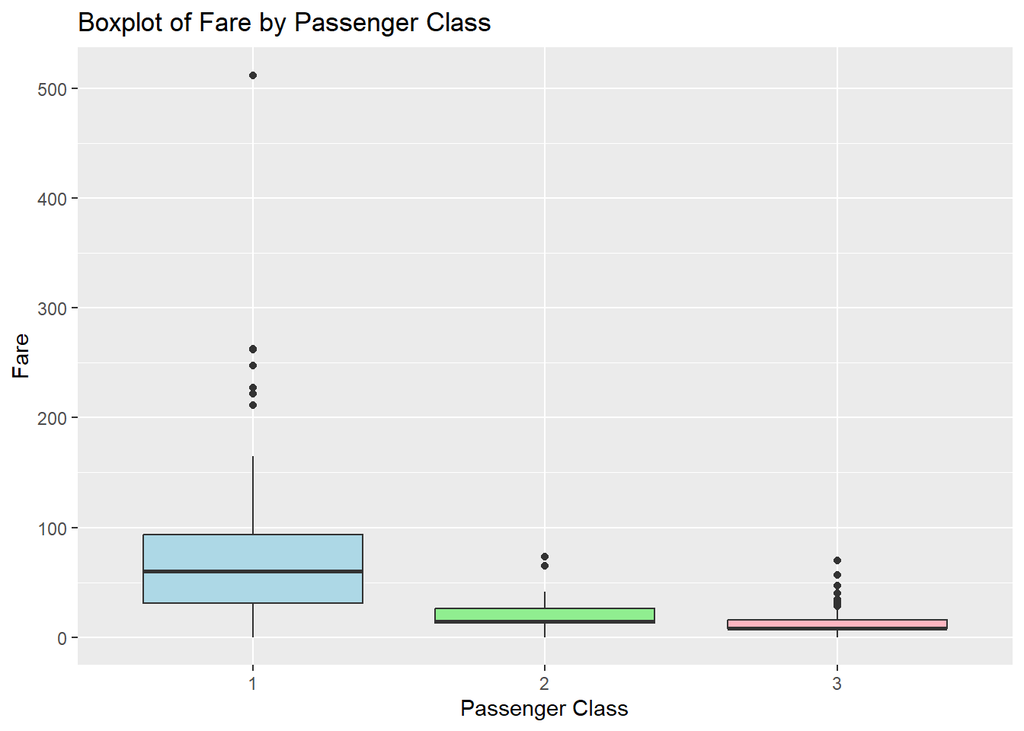

```r
ggplot(titanic, aes(x = factor(Pclass), y = Fare)) +
  geom_boxplot(fill = c("lightblue", "lightgreen", "lightpink")) +
  labs(title = "Boxplot of Fare by Passenger Class", x = "Passenger Class", y = "Fare")
```

```r
#This compares fares across the three passenger classes.
```

5. For two categorical variables: barplot

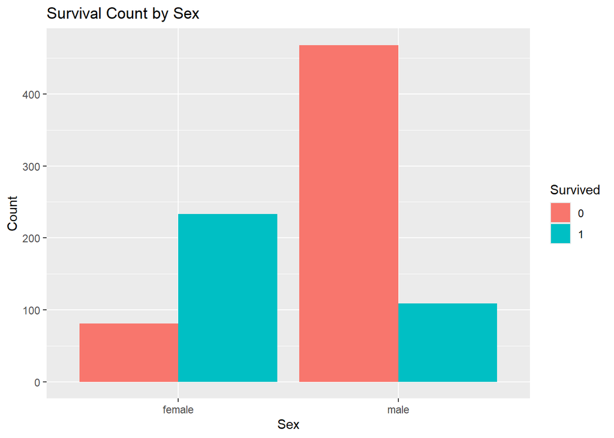

```r
library(ggplot2)

ggplot(titanic, aes(x = Sex, fill = factor(Survived))) +
  geom_bar(position = "dodge") +
  labs(title = "Survival Count by Sex", x = "Sex", y = "Count", fill = "Survived")
```

```r
#This shows the number of male and female passengers who survived or did not survive
```

6. A plot that contains three variables

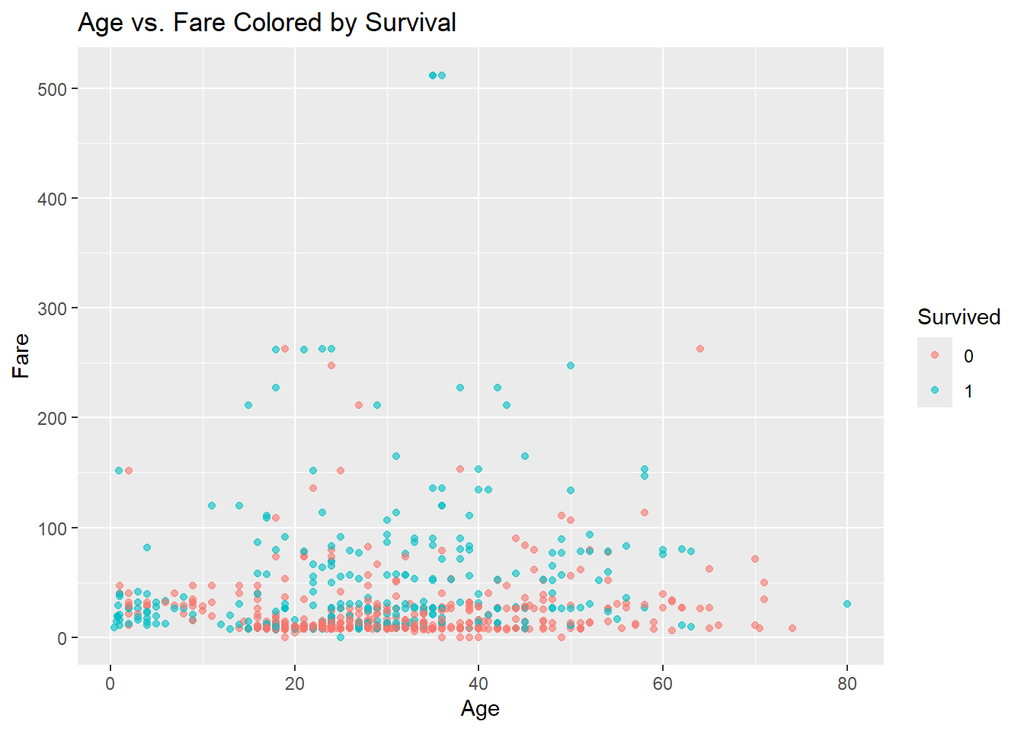

```r
library(ggplot2)

ggplot(titanic, aes(x = Age, y = Fare, color = factor(Survived))) +
  geom_point(alpha = 0.6) +
  labs(title = "Age vs. Fare Colored by Survival",
       x = "Age", y = "Fare", color = "Survived")
```

```r
#This shows the relationship between Age and Fare, with points colored by survival status
```